# Correlaciones entre variables del Censo de Viviendas, Hogares y Personas e ingresos promedios comunales de la CASEN 2017.

VE-CC-AJ

DataIntelligence

Jueves 01-06-2021

Abstract

Calculamos correlaciones entre el ingreso promedio comunal **multiplicado por la población comunal** que llamaremos **ingresos expandidos** extraído de la Casen 2017 y las frecuencias de categorías de respuesta para todas las variables del Censo de viviendas, hogares y personas al 2017, también extraídas a nivel comunal.

Haremos las correlaciones tanto a nivel Urbano como rural.

Importante es aplicar la libreria **dplyr** para evitar que en los filtros se desplieguen series de tiempo.

# 1 Construcción de tablas con frecuencias de respuesta por categoría desde el Censo: **Viviendas**

## 1.1 Pregunta **P01**: Tipo de vivienda

Ésta pregunta posee 10 categorías de respuesta:

1 Casa  
2 Departamento en edificio  
3 Vivienda tradicional indígena (ruka, pae pae u otras)  
4 Pieza en casa antigua o en conventillo  
5 Mediagua, mejora, rancho o choza  
6 Móvil (carpa, casa rodante o similar)  
7 Otro tipo de vivienda particular  
8 Vivienda colectiva  
9 Operativo personas en tránsito (no es vivienda)  
10 Operativo calle (no es vivienda)

```r
tabla_con_clave <- readRDS("../censo_viviendas_con_clave_17.rds")
```

Area: urbano = 1 rural = 2

Estamos cometiendo un sesgo, pues los ingresos que hemos utilizado están calculados a nivel nacional, sin hacer distingos entre el nivel urbano y rural. Ésta diferencia es la que construiremos ahora.

### 1.1.4 Ingresos promedio por comuna a nivel urbano

```r
casen_2017 <- readRDS(file = "../casen_2017_c.rds")
casen_2017_u <- filter(casen_2017, casen_2017$zona == "Urbano")
```

```r
casen_2017_u <- casen_2017_u[!is.na(casen_2017_u$ytotcor),]

Q <- quantile(casen_2017_u$ytotcor, probs=c(.25, .75), na.rm = FALSE)
iqr <- IQR(casen_2017_u$ytotcor)
casen_2017_sin_o <- subset(casen_2017_u, casen_2017_u$ytotcor > (Q[1] - 1.5*iqr) & casen_2017_u$ytotcor < (Q[2]+1.5*iqr))
casen_2017_sin_o <- data.frame(lapply(casen_2017_sin_o, as.character), stringsAsFactors=FALSE)

b <-  as.numeric(casen_2017_sin_o$ytotcor)
a <- casen_2017_sin_o$comuna

promedios_grupales <-aggregate(b, by=list(a), FUN = mean , na.rm=TRUE )

names(promedios_grupales)[1] <- "comuna"
names(promedios_grupales)[2] <- "promedio_i"
promedios_grupales$año <- "2017"

codigos_comunales <- readRDS(file = "../codigos_comunales_2011-2017.rds")
names(codigos_comunales)[1] <- "código"
names(codigos_comunales)[2] <- "comuna"

df_2017 = merge( x = promedios_grupales, y = codigos_comunales, by = "comuna", all.x = TRUE)

library("rio")
x <- import("../Microdato_Censo2017-Personas.csv")

my_summary_data <- x %>%
    group_by(x$COMUNA) %>%
    summarise(Count = n())

names(my_summary_data)[1] <- "comuna"
names(my_summary_data)[2] <- "personas"

# recogemos el campo Comuna:
codigos <- my_summary_data$comuna

# construimos una secuencia llamada rango del 1 al total de filas del dataset:
rango <- seq(1:nrow(my_summary_data))

# Creamos un string que agrega un cero a todos los registros:
cadena <- paste("0",codigos[rango], sep = "")

# El string cadena tiene o 5 o 6 digitos, los cuales siempre deben ser siempre 5 agregandole un cero al inicio de los que tienen 4.
# Para ello extraemos un substring de la cadena sobre todas las filas (rangos) comenzando desde el primero o el segundo y llegando siempre al 6.

cadena <- substr(cadena,(nchar(cadena)[rango])-(4),6)
codigos <- as.data.frame(codigos)
cadena <- as.data.frame(cadena)
comuna_corr <- cbind(my_summary_data,cadena)

names(comuna_corr)[3] <- "código"

df_2017_2 = merge( x = df_2017, y = comuna_corr, by = "código", all.x = TRUE)

df_2017_2$Ingresos_expandidos <- df_2017_2$promedio_i*df_2017_2$personas

head(df_2017_2,5)
```

```
##   código      comuna.x promedio_i  año comuna.y personas Ingresos_expandidos
## 1  01101       Iquique   375676.9 2017     1101   191468         71930106513
## 2  01107 Alto Hospicio   311571.7 2017     1107   108375         33766585496
## 3  01401  Pozo Almonte   316138.5 2017     1401    15711          4966851883
## 4  01405          Pica   330061.1 2017     1405     9296          3068247619
## 5  02101   Antofagasta   368221.4 2017     2101   361873        133249367039
```

```r
saveRDS(df_2017_2, "Ingresos_expandidos_urbano_17.rds")
```

### 1.1.5 Ingresos promedio por comuna a nivel rural

```r
casen_2017 <- readRDS(file = "../casen_2017_c.rds")
casen_2017_u <- filter(casen_2017, casen_2017$zona == "Rural")
```

```r
casen_2017_u <- casen_2017_u[!is.na(casen_2017_u$ytotcor),]

Q <- quantile(casen_2017_u$ytotcor, probs=c(.25, .75), na.rm = FALSE)
iqr <- IQR(casen_2017_u$ytotcor)
casen_2017_sin_o <- subset(casen_2017_u, casen_2017_u$ytotcor > (Q[1] - 1.5*iqr) & casen_2017_u$ytotcor < (Q[2]+1.5*iqr))
casen_2017_sin_o <- data.frame(lapply(casen_2017_sin_o, as.character), stringsAsFactors=FALSE)

b <-  as.numeric(casen_2017_sin_o$ytotcor)
a <- casen_2017_sin_o$comuna

promedios_grupales <-aggregate(b, by=list(a), FUN = mean , na.rm=TRUE )

names(promedios_grupales)[1] <- "comuna"
names(promedios_grupales)[2] <- "promedio_i"
promedios_grupales$año <- "2017"

codigos_comunales <- readRDS(file = "../codigos_comunales_2011-2017.rds")
names(codigos_comunales)[1] <- "código"
names(codigos_comunales)[2] <- "comuna"

df_2017 = merge( x = promedios_grupales, y = codigos_comunales, by = "comuna", all.x = TRUE)

library("rio")
x <- import("../Microdato_Censo2017-Personas.csv")

my_summary_data <- x %>%
    group_by(x$COMUNA) %>%
    summarise(Count = n())

names(my_summary_data)[1] <- "comuna"
names(my_summary_data)[2] <- "personas"

# recogemos el campo Comuna:
codigos <- my_summary_data$comuna

# construimos una secuencia llamada rango del 1 al total de filas del dataset:
rango <- seq(1:nrow(my_summary_data))

# Creamos un string que agrega un cero a todos los registros:
cadena <- paste("0",codigos[rango], sep = "")

# El string cadena tiene o 5 o 6 digitos, los cuales siempre deben ser siempre 5 agregandole un cero al inicio de los que tienen 4.
# Para ello extraemos un substring de la cadena sobre todas las filas (rangos) comenzando desde el primero o el segundo y llegando siempre al 6.
cadena <- substr(cadena,(nchar(cadena)[rango])-(4),6)
codigos <- as.data.frame(codigos)
cadena <- as.data.frame(cadena)
comuna_corr <- cbind(my_summary_data,cadena)

names(comuna_corr)[3] <- "código"

df_2017_2 = merge( x = df_2017, y = comuna_corr, by = "código", all.x = TRUE)

df_2017_2$Ingresos_expandidos <- df_2017_2$promedio_i*df_2017_2$personas

head(df_2017_2,5)
```

```
##   código     comuna.x promedio_i  año comuna.y personas Ingresos_expandidos
## 1  01101      Iquique   272529.7 2017     1101   191468         52180713221
## 2  01401 Pozo Almonte   243272.4 2017     1401    15711          3822052676
## 3  01402       Camiña   226831.0 2017     1402     1250           283538750
## 4  01404        Huara   236599.7 2017     1404     2730           645917134
## 5  01405         Pica   269198.0 2017     1405     9296          2502464414
```

```r
saveRDS(df_2017_2, "Ingresos_expandidos_rural_17.rds")
```

Despleguemos nuevamente las correlaciones con estos ingresos diferenciados por zona:

### 1.1.6 Cálculo de correlaciones a nivel nacional urbano

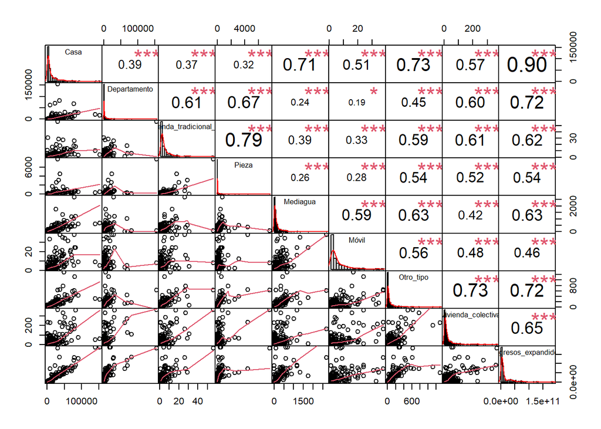

```r
tabla_con_clave_u <- filter(tabla_con_clave, tabla_con_clave$AREA == 1)
b <- tabla_con_clave_u$COMUNA
c <- tabla_con_clave_u$P01
cross_tab =  xtabs( ~ unlist(b) + unlist(c))
tabla <- as.data.frame(cross_tab)
d <-tabla[!(tabla$Freq == 0),]
d$anio <- "2017"

d_t <- filter(d,d$unlist.c. == 1)
for(i in 2:10){
  d_i <- filter(d,d$unlist.c. == i)
  d_t = merge( x = d_t, y = d_i, by = "unlist.b.", all.x = TRUE)
}

# Agregamos un cero a los códigos comunales de 4 dígitos, que queda en la columna llamada **código**:
codigos <- d_t$unlist.b.
rango <- seq(1:nrow(d_t))
cadena <- paste("0",codigos[rango], sep = "")
cadena <- substr(cadena,(nchar(cadena)[rango])-(4),6)
codigos <- as.data.frame(codigos)
cadena <- as.data.frame(cadena)
comuna_corr <- cbind(d_t,cadena)
comuna_corr <- comuna_corr[,-c(1),drop=FALSE]
names(comuna_corr)[31] <- "código"

#Hacemos la unión con los ingresos promedio comunales expandidos:
ingresos_expandidos_2017 <- readRDS("Ingresos_expandidos_urbano_17.rds")
df_2017_2 = merge( x = comuna_corr, y = ingresos_expandidos_2017, by = "código", all.x = TRUE)

# Renombre de columnas
names(df_2017_2)[3] <- "Casa"
names(df_2017_2)[6] <- "Departamento"
names(df_2017_2)[9] <- "Vivienda_tradicional_ind "
names(df_2017_2)[12] <- "Pieza"
names(df_2017_2)[15] <- "Mediagua"
names(df_2017_2)[18] <- "Móvil"
names(df_2017_2)[21] <- "Otro_tipo"
names(df_2017_2)[24] <- "Vivienda_colectiva"

# Correlaciones
my_data <- df_2017_2[, c(3,6,9,12,15,18,21,24,37)]
chart.Correlation(my_data, histogram=TRUE, pch=20)
```

### 1.1.7 Cálculo de correlaciones a nivel nacional rural

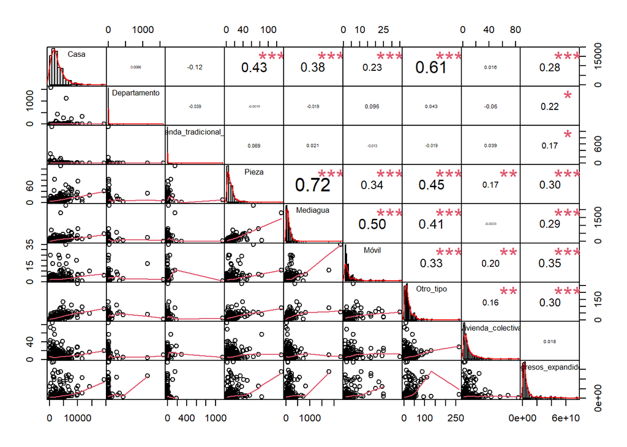

```r
tabla_con_clave_r <- filter(tabla_con_clave, tabla_con_clave$AREA == 2)
b <- tabla_con_clave_r$COMUNA
c <- tabla_con_clave_r$P01
cross_tab =  xtabs( ~ unlist(b) + unlist(c))
tabla <- as.data.frame(cross_tab)
d <-tabla[!(tabla$Freq == 0),]
d$anio <- "2017"

d_t <- filter(d,d$unlist.c. == 1)
for(i in 2:10){
  d_i <- filter(d,d$unlist.c. == i)
  d_t = merge( x = d_t, y = d_i, by = "unlist.b.", all.x = TRUE)
}

# Agregamos un cero a los códigos comunales de 4 dígitos, que queda en la columna llamada **código**:
codigos <- d_t$unlist.b.
rango <- seq(1:nrow(d_t))
cadena <- paste("0",codigos[rango], sep = "")
cadena <- substr(cadena,(nchar(cadena)[rango])-(4),6)
codigos <- as.data.frame(codigos)
cadena <- as.data.frame(cadena)
comuna_corr <- cbind(d_t,cadena)
comuna_corr <- comuna_corr[,-c(1),drop=FALSE]
names(comuna_corr)[31] <- "código"

# Hacemos la unión con los ingresos promedio comunales expandidos:
ingresos_expandidos_2017 <- readRDS("Ingresos_expandidos_rural_17.rds")
df_2017_2 = merge( x = comuna_corr, y = ingresos_expandidos_2017, by = "código", all.x = TRUE)

# Renombre de columnas
names(df_2017_2)[3] <- "Casa"
names(df_2017_2)[6] <- "Departamento"
names(df_2017_2)[9] <- "Vivienda_tradicional_ind "
names(df_2017_2)[12] <- "Pieza"
names(df_2017_2)[15] <- "Mediagua"
names(df_2017_2)[18] <- "Móvil"
names(df_2017_2)[21] <- "Otro_tipo"
names(df_2017_2)[24] <- "Vivienda_colectiva"

# Correlaciones
my_data <- df_2017_2[, c(3,6,9,12,15,18,21,24,37)]
chart.Correlation(my_data, histogram=TRUE, pch=20)
```

¿Con éstas correlaciones tan bajas, utilizamos también la información a nivel rural?, se propone que si, pues aún falta la aplicación de los diferentes modelos en el momento de la regresión lineal.

Parece no ser relevante el análisis a nivel regional por la pequeña cantidad de comunas que hay en cada una que es menor aún considerando las que pertenecen a cada categoría de respuesta.